# Lecture 4: Point Level Models

## Class Intro

- What did we learn last time?
- For Today
  - What is point referenced data?
  - How do we predict the response at unobserved locations?

# Overview of Point Level Models or Geostatistical Models

## Visual Motivation

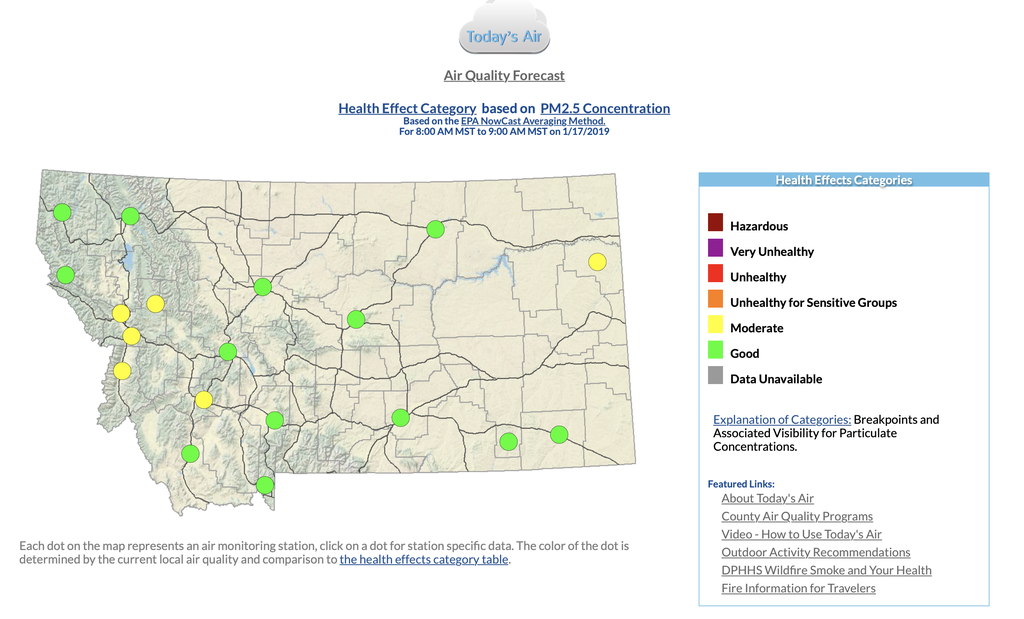

source: airnow.gov

## Basic Notation

- The response, $Y(\boldsymbol{s})$, is a random variable at location(s) $\boldsymbol{s}$
- $\boldsymbol{s}$ varies continuously over the space
- Typically, $\boldsymbol{s} \in \mathcal{R}^2$ or $\boldsymbol{s} \in \mathcal{D}$, where $\mathcal{D} \subset \mathcal{R}^2$, such as Montana.
- $Y(\boldsymbol{s})$ is a stochastic process, or a collection of random variables.
- In spatial settings, $Y(\boldsymbol{s})$ is referred to as a *spatial process*.

## Conceptual Challenge: Questions

#### Goals

- Inference about spatial process $Y(\boldsymbol{s})$
- Create a continous map of air quality, or more generally predict the response at new locations given the partial realization of the process

#### Discussion Questions

- What is the dimension of the spatial process, $Y(\boldsymbol{s})$?
- How are predictions made at unsampled locations, and a related question, what does “inference about a spatial process” mean?

## Conceptual Challenge: Solutions

#### Goals

- Inference about spatial process $Y(\boldsymbol{s})$
- Create a continous map of air quality, or more generally predict the response at new locations given the partial realization of the process

#### Discussion Questions

- What is the dimension of the spatial process, $Y(\boldsymbol{s})$? It is defined across the entire space, so infinite dimensional.
- How are predictions made at unsampled locations, and a related question, what does “inference about a spatial process” mean? the spatial process is assumed to have mean (or covariate) properties as well as a specified covariance structure as a function of distance. Similar to a standard regression model, predictions are made using the covariates and covariance.

## Spatial Covariance

- Spatial covariance is characterized by the distance between locations
- By specifying a structured form for the covariance function, few parameters are necessary
- A covariance function must be symmetric: $Cov(Y(\boldsymbol{s}_1),Y(\boldsymbol{s}_2)) = Cov(Y(\boldsymbol{s}_2),Y(\boldsymbol{s}_1))$
- A common covariance is the exponential covariance, where
  $$Cov(Y(\boldsymbol{s}_1),Y(\boldsymbol{s}_2)) = \sigma^2 \exp(-\phi d_{12}),$$
  where $d_{12}$ is the distance between $\boldsymbol{s}_1$ and $\boldsymbol{s}_2$.

## Exponential Covariance: Questions

The exponential covariance function has two parameters:

$$Cov(Y(\boldsymbol{s}_1),Y(\boldsymbol{s}_2)) = \sigma^2 \exp(-\phi d_{12}),$$

Describe the how the parameters contribute to the covariance:

- $\phi$
- $\sigma^2$

## Exponential Covariance: Solution

The exponential covariance function has two parameters:

$$Cov(Y(\boldsymbol{s}_1),Y(\boldsymbol{s}_2)) = \sigma^2 \exp(-\phi d_{12}),$$

Describe the how the parameters contribute to the covariance:

- $\phi$: controls the correlation. In particular, $\exp(-\phi d_{12})$ will be between 0 and 1 (with $\phi > 0$ and $d_{12} \geq 0$). When $d_{12} \gg \frac{1}{\phi},$ the correlation goes to zero and When $d_{12} \ll \frac{1}{\phi},$ the correlation goes to one. $\frac{1}{\phi}$ is known as the *range parameter*.
- $\sigma^2$: is a scaling parameter associated with the correlation. $\sigma^2$ is called the partial sill

## Exponential Covariance: Nugget

- Spatial models include a *nugget* effect to account point level variability. This can be thought of as measurement error, or randomness inherent in the process.
- Hence for a single point,
  $$Cov(Y(\boldsymbol{s}_i),Y(\boldsymbol{s}_i)) = \sigma^2 \exp(-\phi d_{12}) + \tau^2,$$
- In this setting, $\sigma^2 + \tau^2$ is called the *sill*.

## Joint Distribution

A joint distribution is specified to model the spatial covariance using standard likelihood-based techniques.

- Let $\boldsymbol{Y} := \{Y(\boldsymbol{s}_i) \}$ for locations $\boldsymbol{s_i}, i = 1, \dots, n$
- Then assume
  $$\boldsymbol{Y}|\mu, \boldsymbol{\theta} \sim MVN_n(\mu \boldsymbol{1}_n, \Sigma(\boldsymbol{\theta})),$$
  where $\boldsymbol{\theta}$ is a vector of parameters that determine the variance.

## Parameter Estimation: Questions

- Write out the likelihood for $\boldsymbol{Y}$
- Describe the process for estimating the parameters in the model

## Parameter Estimation: Solutions

- Write out the likelihood for $\boldsymbol{Y}$:
  $$\boldsymbol{Y}|\mu, \boldsymbol{\theta} = (2 \pi) ^{n/2} |\Sigma(\boldsymbol{\theta})|^{-1/2} \exp\left[-\frac{1}{2}(\boldsymbol{Y} - \boldsymbol{1}\mu)^T \Sigma(\boldsymbol{\theta})^{-1} (\boldsymbol{Y} - \boldsymbol{1}\mu) \right]$$
- Describe the process for estimating the parameters in the model maximum likelihood for $\mu$, and $\boldsymbol{\theta}$ or with Bayesian techniques using prior distributions and Markov Chain Monte Carlo

## Gaussian Process

Given that we assume
$$\boldsymbol{Y}|\mu, \boldsymbol{\theta} \sim MVN_n(\mu \boldsymbol{1}_n, \Sigma(\boldsymbol{\theta})),$$

- it is also reasonable to assume that the response at a set of unobserved locations, $\boldsymbol{Y}(\boldsymbol{s^*})$ also follows a multivariate normal distribution.
- this results in an infinite dimensional normal distribution, which is also know as a Gaussian Process (GP)
- prediction, say $\boldsymbol{Y}(\boldsymbol{s^*})|\boldsymbol{Y}(\boldsymbol{s})$ follows a conditional multivariate normal distribution

# Elements of Geostatistical models

## Stationarity

- Assume the spatial process, $\boldsymbol{Y}(\boldsymbol{s})$ has a mean, $\boldsymbol{\mu}(\boldsymbol{s})$, and that the variance of $\boldsymbol{Y}(\boldsymbol{s})$ exists everywhere.
- The process is **strictly stationary** if: for any $n \geq 1$, any set of $n$ sites $\{\boldsymbol{s}_1, \dots, \boldsymbol{s}_n\}$ and any $\boldsymbol{h} \in \mathcal{R}^r$ (typically r =2), the distribution of $(\boldsymbol{Y}(\boldsymbol{s}_1). \dots, \boldsymbol{Y}(\boldsymbol{s+h}_n))$ is the same as $\boldsymbol{Y}(\boldsymbol{s+h}_1)$

## Strict Stationarity

Is this strictly stationary?

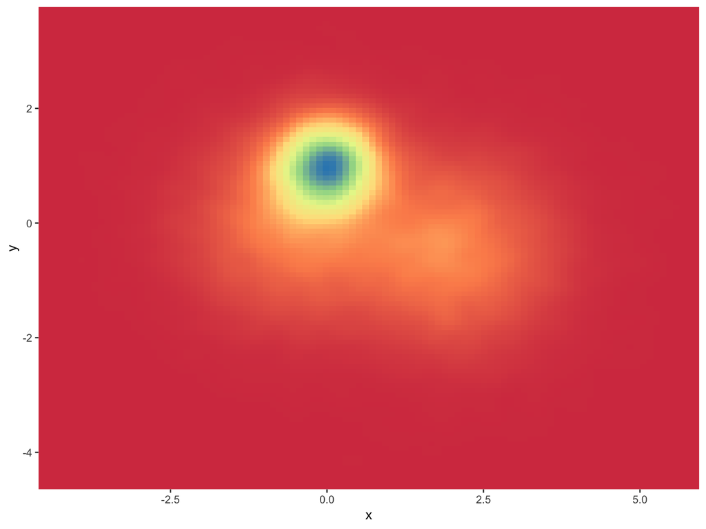

## Weak Stationarity

- Weak stationarity, or second-order stationarity of a spatial process, requires a constant mean and covariance that is a function of $\boldsymbol{h}$, $Cov(\boldsymbol{Y}(\boldsymbol{s}),\boldsymbol{Y}(\boldsymbol{s +h})) = C(\boldsymbol{h}),$ where $C(\boldsymbol{h})$ is a covariance function that only requires the distance between the points.
- Typically with spatial models, the process is assumed to be mean zero as covariates explain the mean structure. So second-order stationarity is primarily focused on the covariance structure.

## Weak Stationarity

Is this weakly stationary?

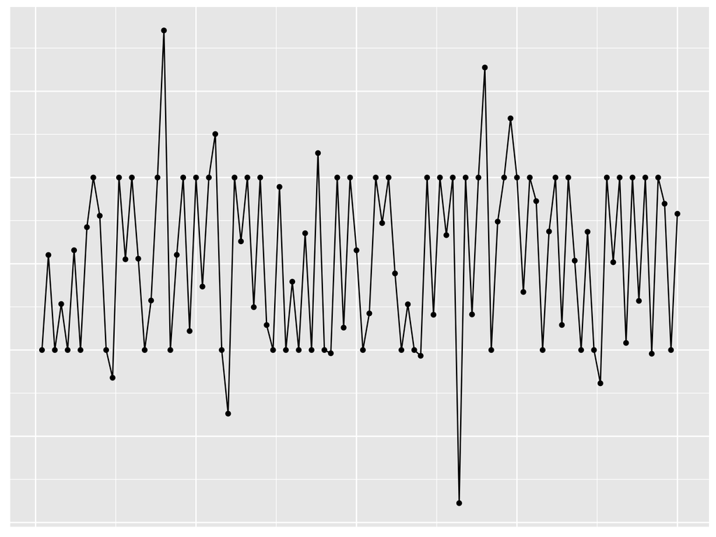

## Intrinsic Stationarity

- A third kind of stationarity, known as intrinsic stationarity, describes the behavior of differences in the spatial process, rather than the data.
- Intrinsic stationarity assumes $E[\boldsymbol{Y}(\boldsymbol{s + h}) -\boldsymbol{Y}(\boldsymbol{s}) ] =0$ then define
  $$E[\boldsymbol{Y}(\boldsymbol{s + h}) - \boldsymbol{Y}(\boldsymbol{s})]^2 = Var(\boldsymbol{Y}(\boldsymbol{s + h}) - \boldsymbol{Y}(\boldsymbol{s})) = 2 \gamma(\boldsymbol{h}),$$
  which only works, and satisfies intrinsic stationarity, if the equation only depends on $\boldsymbol{h}$.

## Variograms

- Intrinsic stationary justifies the use of variograms $2\gamma( \boldsymbol{h})$
- Variograms are often used to visualize spatial patterns:
  - If the distance between points is small, the variogram is expected to be small
  - As the distance between points increases, the variogram increases
- There is a mathematical link between the covariance function $C(\boldsymbol{h})$ and the variogram $2\gamma(\boldsymbol{h})$.

## Isotropy

- If the variogram $2\gamma(\boldsymbol{h})$ depends only on the length of $\boldsymbol{h}$, $||\boldsymbol{h}||,$ and not the direction, then the variogram is isotropic.
- If the direction of $\boldsymbol{h}$ impacts the variogram, then the variogram is anisotropic.

# More about Variograms

## Variogram to the Covariance Function

- Given $C()$, the variogram can easily be recovered
- Going the other way, $2\gamma() \rightarrow C()$, requires additional assumptions

## Linear semivariogram

$$\gamma(d)=
\begin{cases}
\tau^2 + \sigma^2d \; \; \text{if } d > 0\\
0 \; \; \text{otherwise}
\end{cases}$$

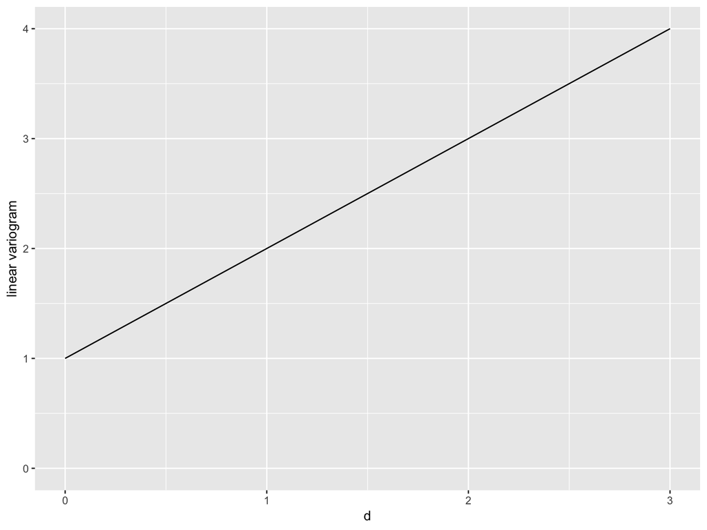

## Spherical semivariogram: exercise

$$\gamma(d)=
\begin{cases}
\tau^2 + \sigma^2 \; \; \text{if } d \geq 1/ \phi\\
\tau^2 + \sigma^2\left[\frac{3\phi d}{2} - \frac{1}{2} (\phi d)^3 \right]\\
0 \; \; \text{otherwise}
\end{cases}$$

- Sketch, or generate in R, a spherical semivariogram
- On this figure label the nugget, sill, partial sill, and range.